# scRNA workshop

2022-09-22

# Reading the data

We begin with setting the seed for all of our computations and reading the files from 10X pipeline.

```r
library(RCurl)
library(Seurat)
localMaxima <- function(x) {
  # Use -Inf instead if x is numeric (non-integer)
  y <- diff(c(-.Machine$integer.max, x)) > 0L
  rle(y)$lengths
  y <- cumsum(rle(y)$lengths)
  y <- y[seq.int(1L, length(y), 2L)]
  if (x[[1]] == x[[2]]) {
    y <- y[-1]
  }
  y
}
x="C:/Users/psergeev/Downloads/SI_GA_G11/filtered_gene_bc_matrices/GRCh38/"
set.seed(100101) #for UMAP
seurat_data <-Read10X(data.dir = x)
```

```
## as(<dgTMatrix>, "dgCMatrix") is deprecated since Matrix 1.5-0; do as(., "CsparseMatrix") instead
```

The next step is to create a Seurat object with a preliminary filtering of cells and genes.

```r
seurat_obj <- CreateSeuratObject(counts = seurat_data, min.cells = 3, min.features = 250)
```

```r
head(seurat_obj)
```

```
##                       orig.ident nCount_RNA nFeature_RNA
## AAACCTGAGCCAGAAC-1 SeuratProject       7435         1494
## AAACCTGAGCTAGCCC-1 SeuratProject      11901         2065
## AAACCTGAGGGCACTA-1 SeuratProject      11365          309
## AAACCTGCAGACGCAA-1 SeuratProject      11108          337
## AAACCTGGTACCAGTT-1 SeuratProject       6215         1681
## AAACCTGGTCTAGCGC-1 SeuratProject       7878         1591
## AAACCTGTCTGCGACG-1 SeuratProject      12026          593
## AAACGGGAGCCAACAG-1 SeuratProject      10712         2113
## AAACGGGGTAGCTCCG-1 SeuratProject       7489         1742
## AAACGGGGTAGGGTAC-1 SeuratProject       7034         1512
```

```r
seurat_obj[["percent.mt"]] <- PercentageFeatureSet( seurat_obj, pattern = "^MT-")
```

We start to introduce our own metrics. Here, we are counting the percentage of mitochondrial genes expressed within each cell. As we know, mitochondrial genes are transcribed within mitochondria. When cells are dying or dead, their external membrane becomes permeable, which leads to the efflux of mRNA from cytoplasm, but not from mitochondria. As a result, we have an increase in mitochondrial genes share.

At this stage we can start with filtering out compromised cells of the low quality. Here huw the raw data looks like now:

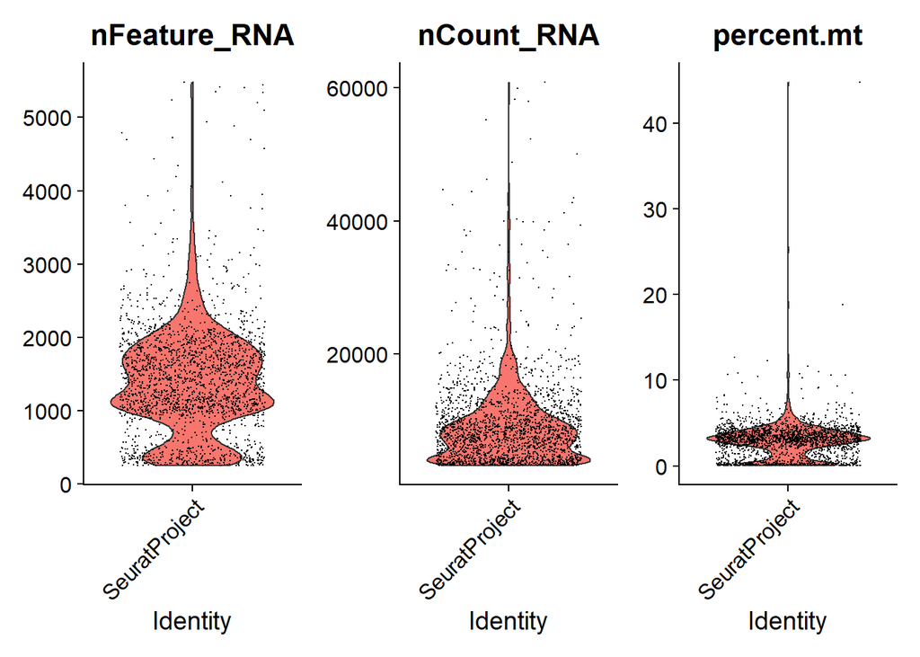

```r
VlnPlot(seurat_obj, features = c("nFeature_RNA", "nCount_RNA", "percent.mt"), ncol = 3)
```

Setting a threshold for a share of mitochondrial genes is challenging, as it is heavily dependent on biology of your samples. There are two main approaches you can use for that. The first one is the set of the fixed threshold. usually it goes around 5%. However, for some cancer cells it might be not the suitable value. And instead of using universal value, we might want to use more adaptive approach, based on modeling and statistics.

Based on empirical experience for MM and AML cases, it seems that most often malignant cells are not exceeding 20% of mitochondrial genes. However, it is pretty high threshold, thus we also empirically found that a choice of the minimal value between triple median and 20% works pretty nice and simple for dead cells removal.

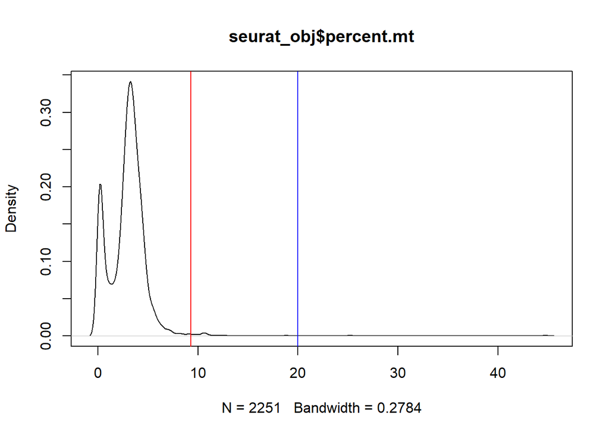

```r
d=density(seurat_obj$percent.mt)
plot(d, main=deparse(substitute(seurat_obj$percent.mt)))
abline(v=median(seurat_obj$percent.mt)*3, col="red")
abline(v=20, col="blue")
```

Another approach will be to use automatic detection of low quality cells using third-party packages. For this example we will show you miQC package, however, it is not the only one, and more are coming regularly.

> *A high proportion of reads mapping to mitochondrial DNA is one sign of a damaged cell, so most analyses will remove cells with mtRNA over a certain threshold, but those thresholds can be arbitrary and/or detrimentally stringent, especially for archived tumor tissues. miQC jointly models both the proportion of reads mapping to mtDNA genes and the number of detected genes with mixture models in a probabilistic framework to identify the low-quality cells in a given dataset.*

```r
suppressPackageStartupMessages({
    library(SingleCellExperiment)
    library(scRNAseq)
    library(scater)
    library(flexmix)
    library(splines)
    library(biomaRt)
    library(miQC)
})
```

This package works with another type of data, suitable for scRNA datasets, which is called SingleCellExperiment. Seurat provides a convenient tool to convert between two types of data. So now we are going to convert our seurat_obj and detect dead cells.

```r
sce=as.SingleCellExperiment(seurat_obj)
mt_genes <- grepl("^mt-",  rownames(sce), ignore.case = T)
feature_ctrls <- list(mito = rownames(sce)[mt_genes])
sce <- addPerCellQC(sce, subsets = feature_ctrls)
```

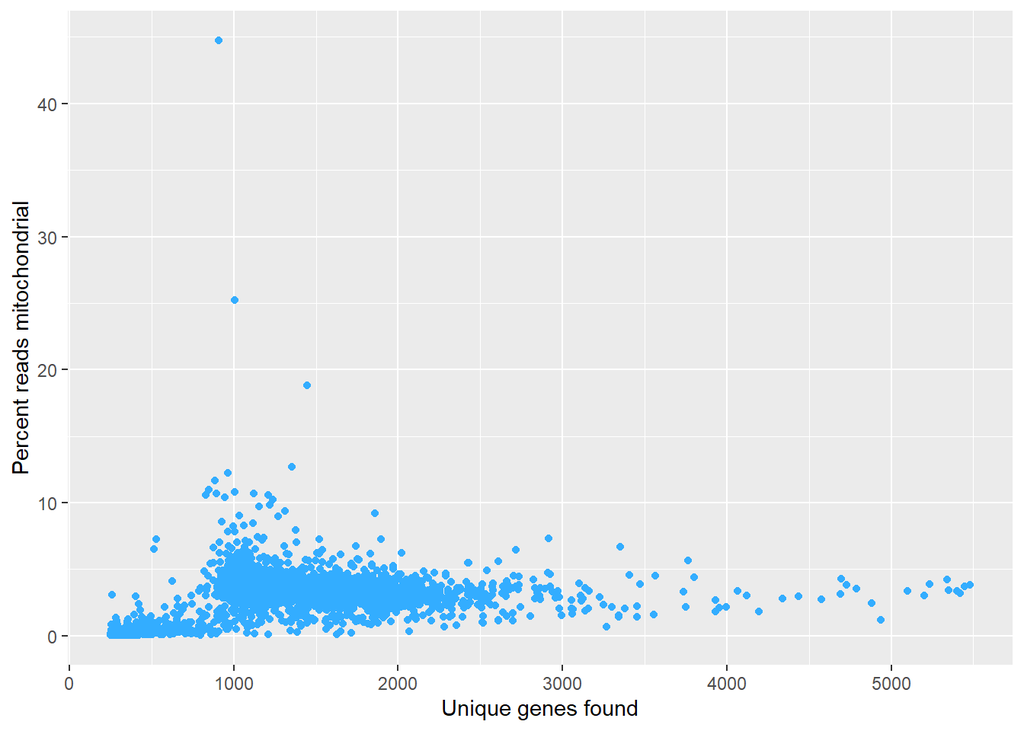

```r
plotMetrics(sce)
```

```r
# model <- mixtureModel(sce)
# plotModel(sce, model)+plotFiltering(sce, model)
```

This package supports also non-linear models as well as modelling based only on mitochondrial information, however, empirically, standard linear models work pretty well for vast majority of cases, so we will not touch upon different tweaks in this workshop. But we encourage to explore it on your own!

```r
# sce <- filterCells(sce, model)
# summary(sce$subsets_mito_percent)
```

```r
df=NULL
#
#
# df["miQC"]=table(colnames(seurat_obj) %in% colnames(sce))[1]
# df["manual"]=table(colnames(seurat_obj) %in% colnames(subset( seurat_obj, subset = percent.mt < ifelse(median(seurat_obj$percent.mt)*3 < 20,median(seurat_obj$percent.mt)*3, 20))))[1]
# df["original"]=ncol(seurat_obj)
# df["intersection"]=length(intersect(colnames(sce),colnames(subset( seurat_obj, subset = percent.mt < ifelse(median(seurat_obj$percent.mt)*3 < 20,median(seurat_obj$percent.mt)*3, 20)))))
# df
```

```r
# d=density(seurat_obj$percent.mt)
# plot(d, main=deparse(substitute(seurat_obj$percent.mt)))
# abline(v=median(seurat_obj$percent.mt)*3, col="red")
# abline(v=20, col="blue")
# abline(v=max(sce$subsets_mito_percent), col="green")
```

```r
#seurat_obj=seurat_obj[,colnames(sce)]
seurat_obj=subset( seurat_obj, subset = percent.mt < ifelse(median(seurat_obj$percent.mt)*3 < 20,median(seurat_obj$percent.mt)*3, 20))
```

Another metrics we introduce is the ratio of log10 transformed number of unique genes detected within a cell to log10 transformed number of transcripts in the same cell. This is essentially a measure of complexity of cells. in our work, samples are frequently contaminated with RBC, which could be filtered out with this metrics. In addition, for illustrative purposes, we add the percentage of hemoglobin and ribosomal genes.

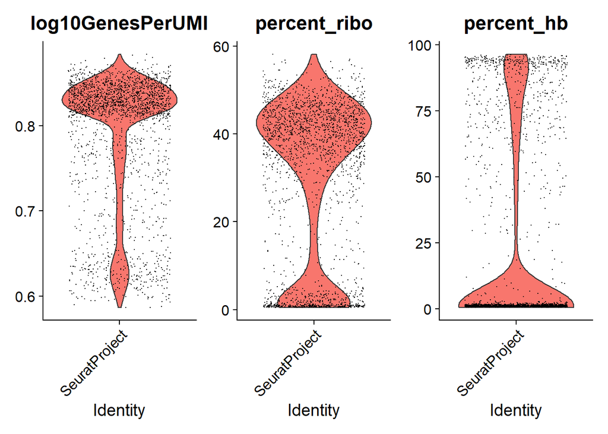

```r
seurat_obj$log10GenesPerUMI <- log10(seurat_obj$nFeature_RNA) / log10(seurat_obj$nCount_RNA)
seurat_obj= PercentageFeatureSet(seurat_obj, "^RP[SL]", col.name = "percent_ribo")
seurat_obj= PercentageFeatureSet(seurat_obj, "^HB[^(P)]", col.name = "percent_hb")
VlnPlot(seurat_obj, features = c("log10GenesPerUMI", "percent_ribo", "percent_hb"))
```

Empirically, cells of the suitable complexity should have this ratio higher than 0.8. Let’s filter out cells with low complexity and compare plots.

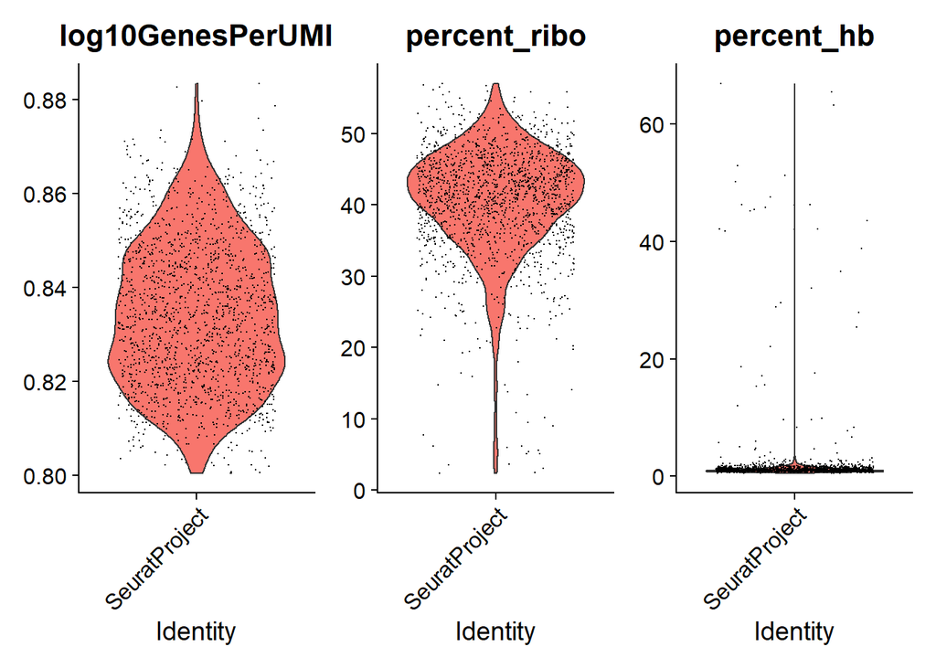

```r
seurat_obj=subset( seurat_obj, subset = log10GenesPerUMI > 0.8)
VlnPlot(seurat_obj, features = c("log10GenesPerUMI", "percent_ribo", "percent_hb"))
```

As you can see, populations with low content of ribosomal genes and high content of hemoglobin genes have been removed. We still have outlying cells with high HB genes content, but as some cancer cells might have them expressed aberrantly, we will not remove them manually.

After that, for sake of computational efficacy, we need to shrink our datasets, removing genes with zero counts, as we removed plenty of cells up to this moment. We keep only those genes, which are epxressed more than in 10 cells. However, this is an arbitrary threshold, so you can vary it, based on the size of you dataset,

```r
counts <- GetAssayData(object = seurat_obj, slot = "counts")
nonzero <- counts > 0
keep_genes <- Matrix::rowSums(nonzero) >=10
filtered_counts <- counts[keep_genes, ]
df=NULL
df["before"]=nrow(seurat_obj)
# Reassign to filtered Seurat object
seurat_obj <- CreateSeuratObject(filtered_counts, meta.data = seurat_obj@meta.data)
df["after"]=nrow(seurat_obj)
df
```

```
## before  after
##  15072  11997
```

After removing unwanted cells from the dataset and shrinking, we need to normalize the data. By default, “LogNormalize” method is used with a further multiplication normalized values for each cell by a scale factor, and log-transforms the result. By default, scale factor is 10000, however, we use 1,000,000 factor, to make it similar to the traditional CPM values. Normalized values are stored in `seurat_obj[["RNA"]]@data.`

```r
seurat_obj <- NormalizeData(seurat_obj, verbose = TRUE, scale.factor = 1000000)
```

To make our analyzed more focused on the genes, representing the biological difference of cells, in other words, the most variable genes. By default, we are aimed at 2000 features to identify.

```r
seurat_obj <- FindVariableFeatures(seurat_obj, selection.method = "vst", nfeatures = 2000)
# Identify the 10 most highly variable genes
top10 <- head(VariableFeatures(seurat_obj), 10)

# plot variable features with and without labels
plot1 <- VariableFeaturePlot(seurat_obj)
plot2 <- LabelPoints(plot = plot1, points = top10, repel = TRUE)
```

```
## When using repel, set xnudge and ynudge to 0 for optimal results
```

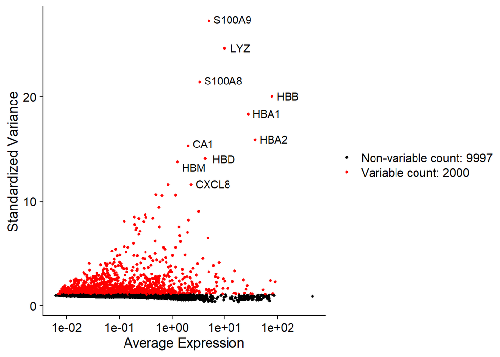

```r
plot2
```

It is always a good idea to check the plots and assess the results, especially, when you set thresholds manually.

Let’s go back to the very beginning and examine those plots one more time.

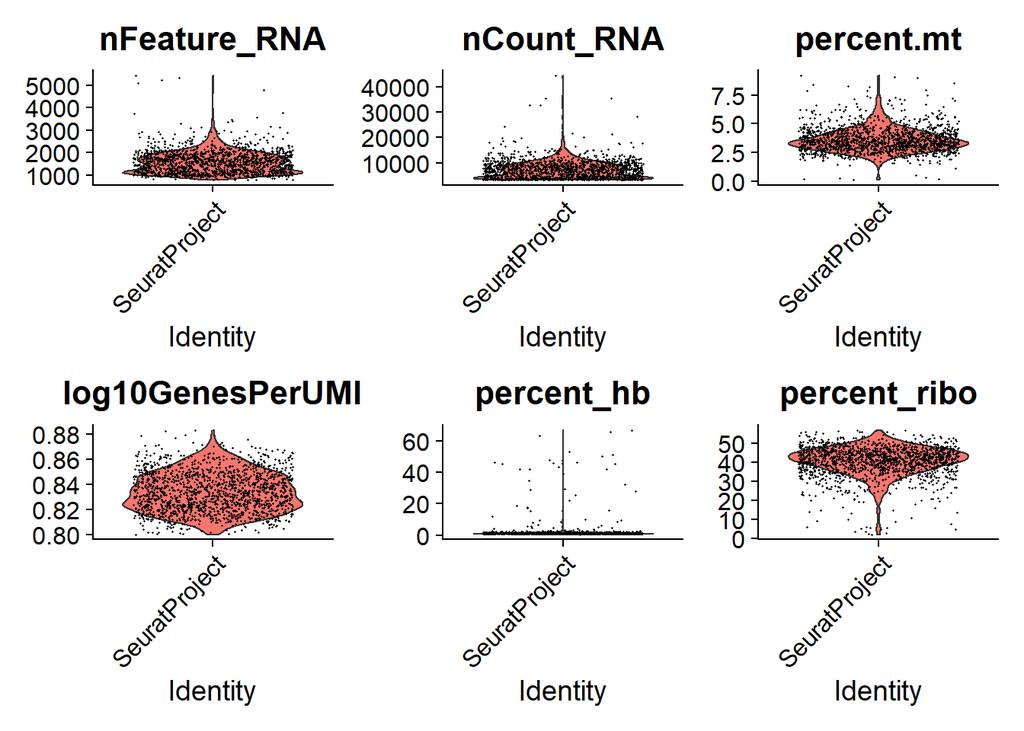

```r
VlnPlot(seurat_obj, features = c("nFeature_RNA", "nCount_RNA", "percent.mt", "log10GenesPerUMI", "percent_hb", "percent_ribo"), ncol = 3)
```

On nFeature_RNA plot we can see one small peak in the top. These cells might be doublets. In my opinion, the identification of doublets is one of the hardest parts of QC. There are also manual and automatic approaches. For example, we used DoubletFinder, which according to [this](https://www.sciencedirect.com/science/article/pii/S2405471220304592) publication showed the best detection accuracy.

```r
library(DoubletFinder)
seurat_obj <- ScaleData(seurat_obj, features = rownames(seurat_obj))
seurat_obj <- RunPCA(seurat_obj, features = VariableFeatures(object = seurat_obj))
```

```
## PC_ 1
## Positive:  CD3E, CCL5, CD52, B2M, ARL4C, GZMH, CD3D, CST7, SPOCK2, RORA
##     CD48, IL32, TRBC2, FGFBP2, IL7R, SYNE2, GZMM, CD2, ETS1, KLRD1
##     ATG2A, KLF2, TUBA4A, GNLY, RUNX3, GZMB, HLA-B, TRAC, GZMA, CD69
## Negative:  CAT, SOX4, CFD, GPX1, AIF1, AZU1, HMGB3, ELANE, CLEC11A, TSC22D1
##     GLUL, MGST1, MPO, CA2, C1QTNF4, MS4A3, CTSG, NUCB2, CSTA, TUBB
##     IRF2BP2, AREG, HIST2H2BE, HOXA10, IMPDH2, HIST1H1C, EREG, CST3, STMN1, FOXC1
## PC_ 2
## Positive:  AREG, ELANE, AZU1, SOX4, C1QTNF4, HNRNPA1, TMSB4X, H3F3B, PTMA, MPO
##     RPS2, FTH1, MS4A3, TSC22D1, CTSG, CLEC11A, EREG, CFD, HIST2H2BE, HMGB3
##     EEF1B2, HIST1H1C, AIF1, GMDS, TWISTNB, HIST1H2BC, CALR, NEU4, KRT18, HIST1H2AC
## Negative:  HBB, CD36, HBA2, HBA1, GATA1, GFI1B, CD52, S100A6, LGALS1, LGALS3
##     HLA-DRB1, TUBG1, RHAG, S100A4, CD48, MT2A, NCAPG, KLF1, HLA-DRA, ADD2
##     UBE2T, SPTA1, MYH10, HLA-DPA1, TOP2A, MKI67, CD74, GYPA, GYPB, MINPP1
## PC_ 3
## Positive:  GATA1, HBB, HBA1, HBA2, GYPB, ADD2, KLF1, TMEM56, GYPA, RHAG
##     MINPP1, SOX6, NCAPG, CDK1, CCNA2, TRIM10, SPTA1, RAB6B, GFI1B, RFESD
##     RHCE, ANK1, UBE2T, MKI67, TUBG1, MYH10, HOXB9, HBQ1, CTSE, TAL1
## Negative:  VCAN, FCN1, CYBB, S100A12, SERPINA1, NCF2, S100A8, S100A9, PLBD1, RAB31
##     CD14, MS4A6A, LILRA5, TGFBI, JAML, MAFB, FGL2, IGSF6, FCER1G, CLEC7A
##     IFI30, RP11-1143G9.4, LRRC25, LILRB2, FPR1, LGALS2, HCK, CLEC4E, SLC7A7, FGR
## PC_ 4
## Positive:  HBB, HBA2, HBA1, FTH1, RAB6B, TRIM10, TMEM56, SOX6, RHCE, TSPO2
##     GYPA, RP11-85G21.3, CTSL, FTL, PDZK1IP1, MIR22HG, DHRS13, RFESD, SPTA1, CD36
##     ACHE, SELENBP1, TMOD1, HEMGN, SLC4A1, CPOX, OSBP2, CKAP2L, AQP1, HJURP
## Negative:  BTG1, IGLL1, STMN1, HSPA8, CXCR4, B2M, PMAIP1, RAC2, HLA-A, PFN1
##     CD69, NME1, HLA-C, ATF3, TMSB4X, NREP, SELL, PHB, PSME2, TPI1
##     CNBP, CYBA, PLAC8, ENO1, HLA-B, TSC22D3, IL2RG, ZFP36L2, JUN, NKG7
## PC_ 5
## Positive:  ST6GALNAC1, KCNH2, APOE, GOLM1, FAM178B, KEL, FAM89A, APOC1, APOL4, MAOA
##     PYCR1, NXF3, CNRIP1, ADD2, XK, CYP7B1, NFE2L3, CPED1, FHL2, LINC01133
##     RP11-277P12.20, IFI27, ARV1, MTSS1, TFR2, ANK1, PIP5K1B, MLLT3, REEP6, BMP2K
## Negative:  TOP2A, AURKB, ASPM, UBE2C, BIRC5, KIF2C, MKI67, SKA3, HMMR, DLGAP5
##     CKAP2L, SHCBP1, NCAPH, NUF2, SPC24, TPX2, TK1, CCNA2, NCAPG, CDCA3
##     TROAP, NEK2, TYMS, GTSE1, CENPA, SGOL1, DIAPH3, KIF15, CENPF, POLQ
```

```r
seurat_obj <- RunUMAP(seurat_obj, dims = 1:10)
```

```r
#DimPlot(seurat_obj, reduction = "umap")

seurat_obj <- FindNeighbors(seurat_obj, dims = 1:10)
seurat_obj <- FindClusters(seurat_obj, resolution = 0.5)
```

```
## Modularity Optimizer version 1.3.0 by Ludo Waltman and Nees Jan van Eck
##
## Number of nodes: 1610
## Number of edges: 55741
##
## Running Louvain algorithm...
## Maximum modularity in 10 random starts: 0.8559
## Number of communities: 7
## Elapsed time: 0 seconds
```

```r
sweep.res.list <- paramSweep_v3(seurat_obj, PCs = 1:10, sct = FALSE)
```

[output not shown]

```
## [1] "Creating artificial doublets for pN = 5%"
## [1] "Creating Seurat object..."
## [1] "Normalizing Seurat object..."
## [1] "Finding variable genes..."
## [1] "Scaling data..."
```

[output not shown]

[output cut: 24 more lines]

[output not shown]

[output cut: 24 more lines]

[output not shown]

[output cut: 24 more lines]

[output not shown]

[output cut: 24 more lines]

[output not shown]

[output cut: 24 more lines]

[output not shown]

[output cut: 19 more lines]

```r
sweep.stats <- summarizeSweep(sweep.res.list, GT = FALSE)
```

```
## Copyright M. P. Wand 1997-2009
```

```r
bcmvn <- find.pK(sweep.stats)
```

[figure not shown]

```r
bcmvn.max <- bcmvn[which.max(bcmvn$BCmetric),]
optimal.pk <- bcmvn.max$pK
optimal.pk <- as.numeric(levels(optimal.pk))[optimal.pk]

## Homotypic doublet proportion estimate
annotations <- seurat_obj@meta.data$seurat_clusters
homotypic.prop <- modelHomotypic(annotations)
nExp.poi <- round(optimal.pk * nrow(seurat_obj@meta.data)) ## Assuming 7.5% doublet formation rate - tailor for your dataset
nExp.poi.adj <- round(nExp.poi * (1 - homotypic.prop))

# run DoubletFinder
seurat_obj <- doubletFinder_v3(seu = seurat_obj,
                                 PCs = 1:10,
                                 pK = optimal.pk,
                                 nExp = nExp.poi.adj)
```

```
## [1] "Creating 537 artificial doublets..."
## [1] "Creating Seurat object..."
## [1] "Normalizing Seurat object..."
## [1] "Finding variable genes..."
## [1] "Scaling data..."
```

```
## [1] "Running PCA..."
## [1] "Calculating PC distance matrix..."
## [1] "Computing pANN..."
## [1] "Classifying doublets.."
```

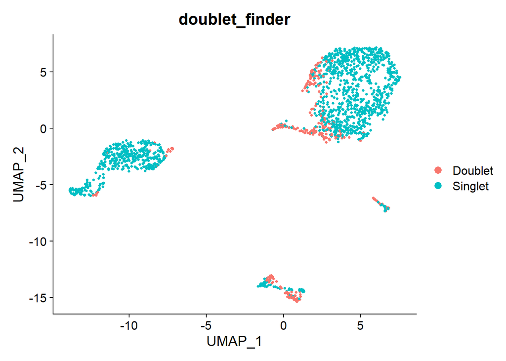

```r
metadata <- seurat_obj@meta.data
colnames(metadata)[length(colnames(metadata))] <- "doublet_finder"
seurat_obj@meta.data <- metadata
DimPlot(seurat_obj, reduction = "umap", group.by = "doublet_finder")
```

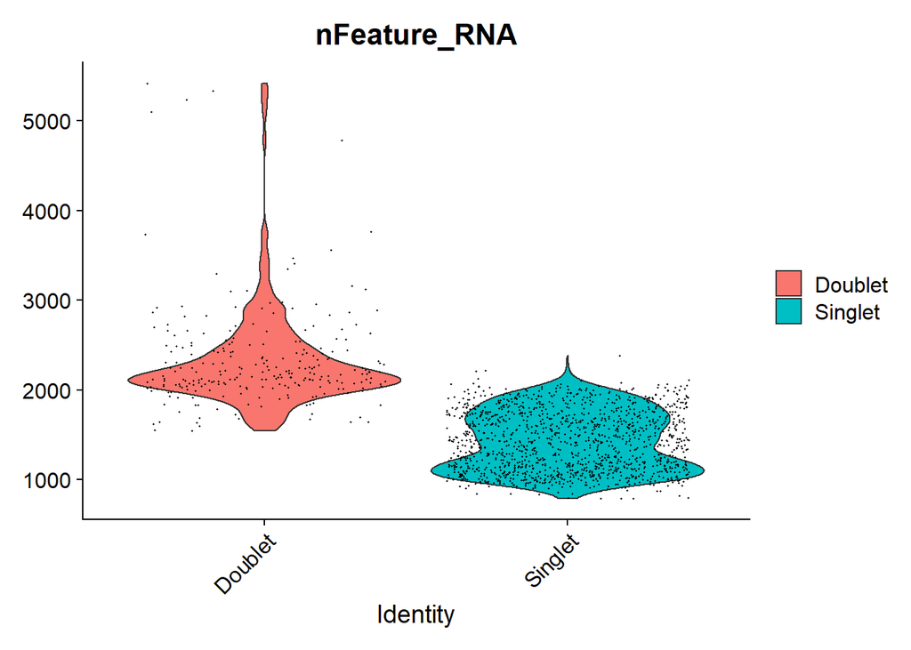

```r
VlnPlot(seurat_obj, "nFeature_RNA", group.by = "doublet_finder")
```

The manual approach is much less sophisticated and is based on the assumption that doublets and multiplets will have exceptionally high numbers of unique transcripts identified. Therefore, we can either set a manual threshold if we know the properties of our sample. Alternatively, assuming that cells should have normal or skew normal distribution, we can set a threshold on the first local minimum found after our local maximum. like that:

```r
library(pastecs)
```

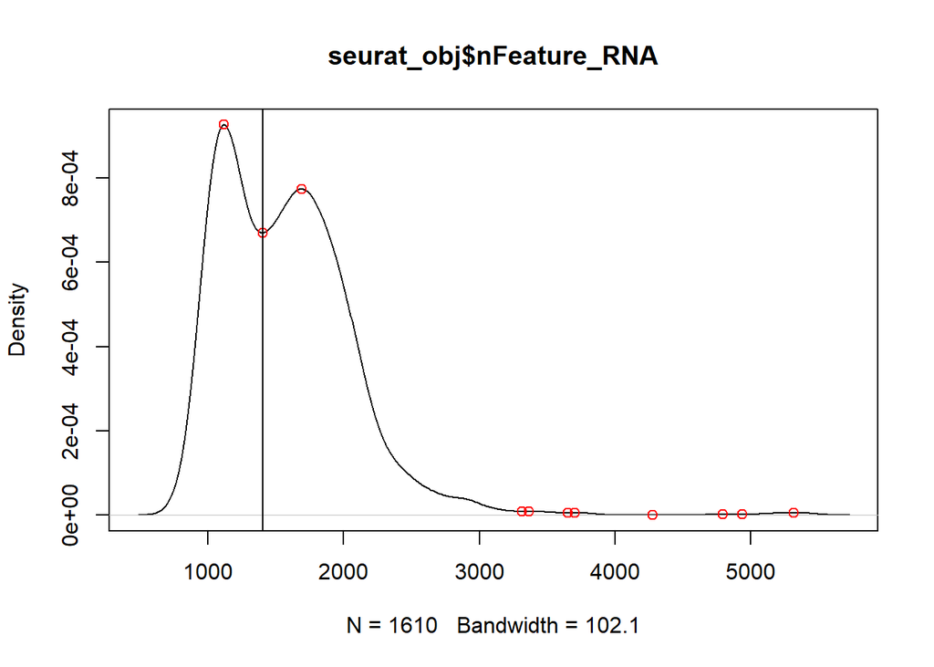

```r
d=density(seurat_obj$nFeature_RNA)
ts_y<-ts(d$y)
tp<-turnpoints(ts_y)
plot(d, main=deparse(substitute(seurat_obj$nFeature_RNA))); points(d$x[tp$tppos],d$y[tp$tppos],col="red");minima=d$x[tp$tppos][seq(1:length(d$y[tp$tppos]))[!seq(1:length(d$y[tp$tppos])) %in% localMaxima(d$y[tp$tppos])]][1]; abline(v=minima)
```

```r
table(seurat_obj$doublet_finder)
```

```
##
## Doublet Singlet
##     260    1350
```

```r
table(seurat_obj$nFeature_RNA>=minima)
```

```
##
## FALSE  TRUE
##   660   950
```

```r
length(intersect(colnames(seurat_obj)[seurat_obj$doublet_finder=="Doublet"], colnames(seurat_obj)[seurat_obj$nFeature_RNA>=minima]))
```

```
## [1] 260
```

Both methods might be wrong in some cases, and quite a lot of tutorials and papers omit this step up until clustering step, where they manually detect clusters with mixed phenotype. Also, it is worthwhile to mention that there are several tools, written for Python or R with the similar functionality.